# Code explainer: Accuracy of the Physicians’ Intuitive Risk Estimation in the Diagnostic Management of Pulmonary Embolism: An Individual Patient Data Meta-Analysis

## Research objective

In patients suspected of pulmonary embolism (PE), physicians often rely on an intuitive estimation (‘gestalt’) of PE presence. This study assessed the diagnostic accuracy of gestalt in diagnosing PE across subgroups. An individual patient data meta-analysis including patients suspected of PE was performed. The primary outcome was the diagnostic accuracy of gestalt for diagnosing PE, quantified as a risk ratio (RR) between gestalt and PE from a two-stage random-effect log-binomial meta-analysis regression as well as gestalts’ sensitivity and specificity from a bivariate generalized linear mixed-effects model.

Since the empirical data presented in the manuscript is not publicly available, we simulated a dataset that can be used to run the code.  
We emphasize that this dataset does not contain any meaningful information.

## How to run the analysis

To reproduce the example based on simulated data, we recommend the following steps:

- Download or clone the code (for instance via Code<> $\rightarrow$ Download ZIP, or by cloning the repository)
- Open the project in RStudio using IPDMA-PE.Rproj
- Make sure the required packages are installed (found under `./2_packages.R`)

All analyses can now be performed by running the file `./1_exe.R`. The results are stored as three pdf-figures under `./figures/` and eight docx-tables under `./tables/`. Below, we explain what the script does and how.

## Background on the script

The file `./1_exe.R` exists of three parts:

- reading in the data
- performing descriptive analyses
- performing main analyses

All user-defined functions can be found in the file `./4_helpers.R`.

### Reading in the data

Since the empirical data presented in the manuscript is not publicly available, we simulated a dataset that can be used to run the code.  
We emphasize that this dataset does not contain any meaningful information.  
The simulated data are stored under `./data/simulated_data.rds`. Loading this data set opens a dataframe with 100,000 rows and 15 variables, representing 10 imputations of a 10,000-observations data set.  
Alternatively, data could be simulated using the file `./3_simulate_data.R`.

| .imp | .id | study | age | PEdiagn | gestalt | pub_before_2010 | prev_VTE | HR_100 | hemoptysis | cancer | symp_dvt | immosurg | sex | chf |
| --- | --- | --- | --- | --- | --- | --- | --- | --- | --- | --- | --- | --- | --- | --- |
| 1 | 1 | 5 | 65.9 | 0 | 0 | 0 | 0 | 0 | 1 | 0 | 0 | 0 | 1 | 0 |
| 1 | 2 | 4 | 65.2 | 1 | 0 | 0 | 0 | 0 | 0 | 0 | 0 | 0 | 0 | 1 |
| 1 | 3 | 3 | 64.3 | 1 | 0 | 0 | 1 | 0 | 0 | 1 | 0 | 0 | 1 | 0 |
| 1 | 4 | 1 | 63.7 | 0 | 0 | 1 | 1 | 0 | 0 | 0 | 0 | 0 | 0 | 0 |
| 1 | 5 | 3 | 64.1 | 1 | 0 | 0 | 0 | 0 | 1 | 1 | 0 | 0 | 0 | 0 |
| 1 | 6 | 1 | 62.8 | 0 | 0 | 0 | 0 | 0 | 1 | 0 | 0 | 0 | 0 | 0 |

…

|  | .imp | .id | study | age | PEdiagn | gestalt | pub_before_2010 | prev_VTE | HR_100 | hemoptysis | cancer | symp_dvt | immosurg | sex | chf |
| --- | --- | --- | --- | --- | --- | --- | --- | --- | --- | --- | --- | --- | --- | --- | --- |
| 10001 | 2 | 1 | 5 | 65.9 | 1 | 0 | 0 | 1 | 0 | 0 | 0 | 0 | 0 | 0 | 0 |
| 10002 | 2 | 2 | 4 | 65.2 | 1 | 0 | 0 | 0 | 0 | 0 | 0 | 0 | 0 | 0 | 1 |
| 10003 | 2 | 3 | 3 | 64.3 | 1 | 0 | 0 | 1 | 0 | 0 | 1 | 0 | 0 | 1 | 0 |
| 10004 | 2 | 4 | 1 | 63.7 | 0 | 0 | 1 | 0 | 0 | 0 | 0 | 0 | 0 | 0 | 0 |
| 10005 | 2 | 5 | 3 | 64.1 | 1 | 0 | 0 | 0 | 0 | 1 | 1 | 0 | 0 | 0 | 0 |
| 10006 | 2 | 6 | 1 | 62.8 | 0 | 0 | 0 | 0 | 0 | 1 | 0 | 0 | 0 | 0 | 0 |

### Performing descriptive analyses

##### Missingness

The missingness in the simulated data is described using the function `prop_miss_table` from the `./4_helpers.R` file. It outputs the following table in the `./tables/` folder.

| variable | nmiss | n | propmiss |
| --- | --- | --- | --- |
| PEdiagn | 2977 | 10000 | 0.2977 |
| gestalt | 2977 | 10000 | 0.2977 |
| pub_before_2010 | 2977 | 10000 | 0.2977 |
| prev_VTE | 2977 | 10000 | 0.2977 |
| HR_100 | 2977 | 10000 | 0.2977 |
| hemoptysis | 2977 | 10000 | 0.2977 |
| cancer | 2977 | 10000 | 0.2977 |
| symp_dvt | 2977 | 10000 | 0.2977 |
| immosurg | 2977 | 10000 | 0.2977 |
| sex | 2977 | 10000 | 0.2977 |
| chf | 2977 | 10000 | 0.2977 |
| cld | 2977 | 10000 | 0.2977 |
| setting | 2977 | 10000 | 0.2977 |
| study | 0 | 10000 | 0.0000 |
| age | 0 | 10000 | 0.0000 |

##### Sample size

The number of individuals with gestalt positive and diagnosed with pulmonary embolism in the simulated data are described in each individual study. The code under ‘sample size’ outputs the following table in the `./tables/` folder.

| Study | Overall sample size | Individuals with final PE (prop) | Gestalt-positive individuals |
| --- | --- | --- | --- |
| 5 | 736 | 151 (0.2) | 109 (0.15) |
| 4 | 1483 | 362 (0.24) | 253 (0.17) |
| 3 | 1876 | 517 (0.28) | 356 (0.19) |
| 1 | 2035 | 632 (0.31) | 414 (0.2) |
| 6 | 1788 | 603 (0.34) | 393 (0.22) |
| 2 | 1373 | 520 (0.38) | 378 (0.28) |
| 0 | 709 | 316 (0.45) | 205 (0.29) |

##### RR individual studies

The relative risk (RR) of pulmonary embolism for gestalt positive versus gestalt negative is estimated in each individual study of the simulated data. The stability of estimates per study can be evaluated before estimates are pooled in the random-effects log-binomial model of the main analysis.

The code under ‘RR per individual study’ outputs the figure below in the `./figures/` folder. It uses the function `estimating_log_RR_overall()` from the `./4_helpers.R` file to estimate the RR in each study pooled over the 10 imputed data sets and uses the function `forest()` from the $\texttt{metafor}$ package to plot the forestplot.

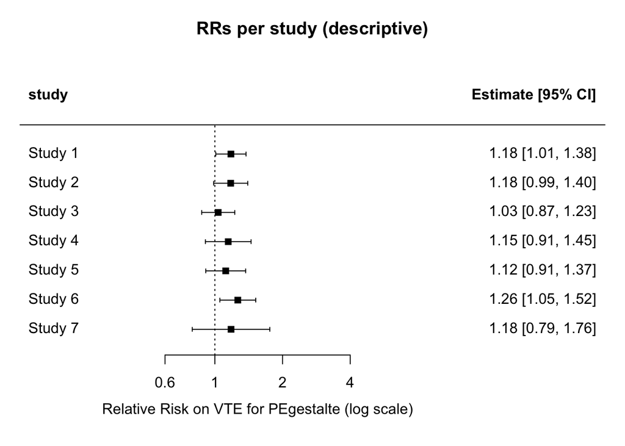

##### Sensitivity individual studies

The sensitivity of gestalt in diagnosing pulmonary embolism is estimated in each individual study of the simulated data. The estimate per study can be evaluated before estimates are pooled in the bivariate generalized linear mixed-effects model of the main analysis.

The code under ‘sensitivity per individual study’ outputs the figure below in the `./figures/` folder. It uses the function `estimating_sens_per_study()` from the `./4_helpers.R` file to estimate the sensitivity in each study pooled over the 10 imputed data sets and uses the function `forest()` from the $\texttt{metafor}$ package to plot the forestplot.

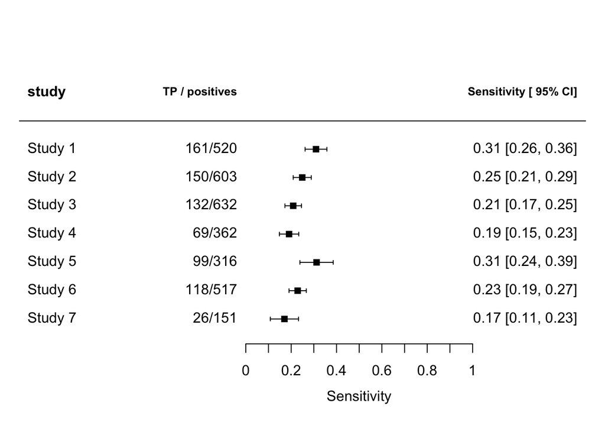

##### Specificity individual studies

The specificity of gestalt in diagnosing pulmonary embolism is estimated in each individual study of the simulated data. The estimate per study can be evaluated before estimates are pooled in the bivariate generalized linear mixed-effects model of the main analysis.

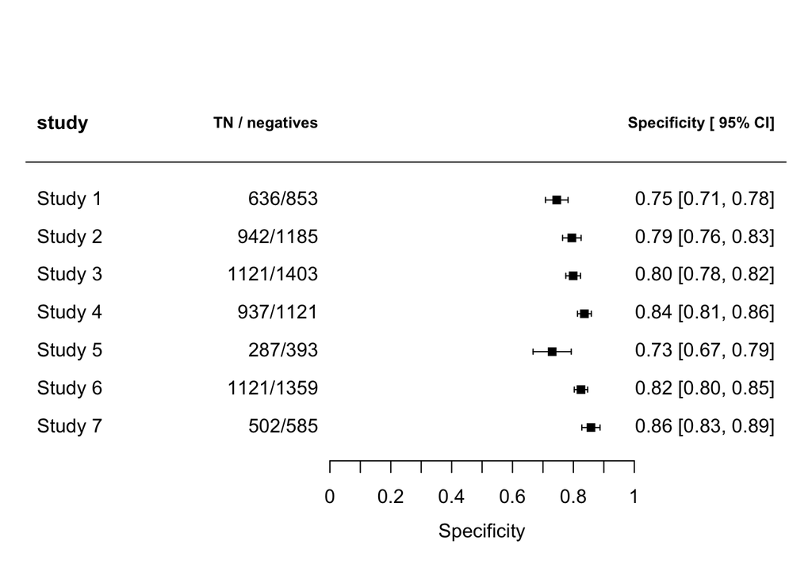

### Performing main analyses

This part of the script describes how to arrive at the main results, being the RR pooled over all individual studies using a random-effects log-binomial model and the sensitivity and specificity pooled over all individual studies using a bivariate generalized linear mixed-effects model.  
The script illustrates how to perform the subgroup analyses for the variable ‘sex’. This analysis is repeated in all subgroups of interest to generate figure 2 of the main text.

##### RR over all individual studies – example for entire population

Similar to above, the function `estimating_log_RR_overall()` from the file `./4_helpers.R` estimates the RR in each individual study. Subsequently, the function `rma()` from the $\texttt{metafor}$ package is used to arrive at the overall estimate.

Overall RR for positive versus negative gestalt on risk of pulmonary embolism diagnosis (in simulated data)

[output not shown]

The same analysis is performed for subgroups of females and males.

##### Sensitivity and specificity over all individual studies – example for females

The function `extract_subset_input_sensspec()` is used to estimate the swnsitivity and specificity over all individual studies, which combines the output of `estimating_sensspec_input_per_study()`, both functions in the file `./4_helpers.R`. It uses the `glmer()` from the $\texttt{lme4}$ package is for the bivariate generalized linear mixed-effects model.

Sensitivity and specificity of gestalt for diagnosing pulmonary embolism in females (in simulated data)

|  | Pooled accuracy measure (95% CI) |
| --- | --- |
| Sensitivity | 0.26 (0.21 to 0.31) |
| Specificity | 0.78 (0.75 to 0.81) |

The same analysis is performed for the entire population and the subgroup of males.